# Exploración de datos IRIS

## Explorando multivariables

Covarianza de dos variables

```r
cov(mydata$Sepalo.Longitud, mydata$Petalo.Longitud)
```

```
## [1] 1.273682
```

Correlacion de dos variables

```r
cor(mydata$Sepalo.Longitud, mydata$Petalo.Longitud)
```

```
## [1] 0.8717542
```

De los resultados anteriores, podemos ver que la correlación entre Sepalo.Longitud y Petalo.Longitud es 0.87, lo que significa que están relacionados positivamente entre sí.

Explorando la correlación de las cuatro variables numéricas:

```r
cor(mydata[,1:4])
```

```
##                 Sepalo.Longitud Sepalo.Ancho Petalo.Longitud Petalo.Ancho
## Sepalo.Longitud       1.0000000   -0.1093692       0.8717542    0.8179536
## Sepalo.Ancho         -0.1093692    1.0000000      -0.4205161   -0.3565441
## Petalo.Longitud       0.8717542   -0.4205161       1.0000000    0.9627571
## Petalo.Ancho          0.8179536   -0.3565441       0.9627571    1.0000000
```

La longitud del sépalo y el ancho del pétalo están muy relacionados, así como Petalo.Longitud y Petalo.Ancho. Por el contrario, Sepalo.Ancho tiene una relación débilmente negativa con las otras tres variables.

Gráfico de dispersión para dos variables

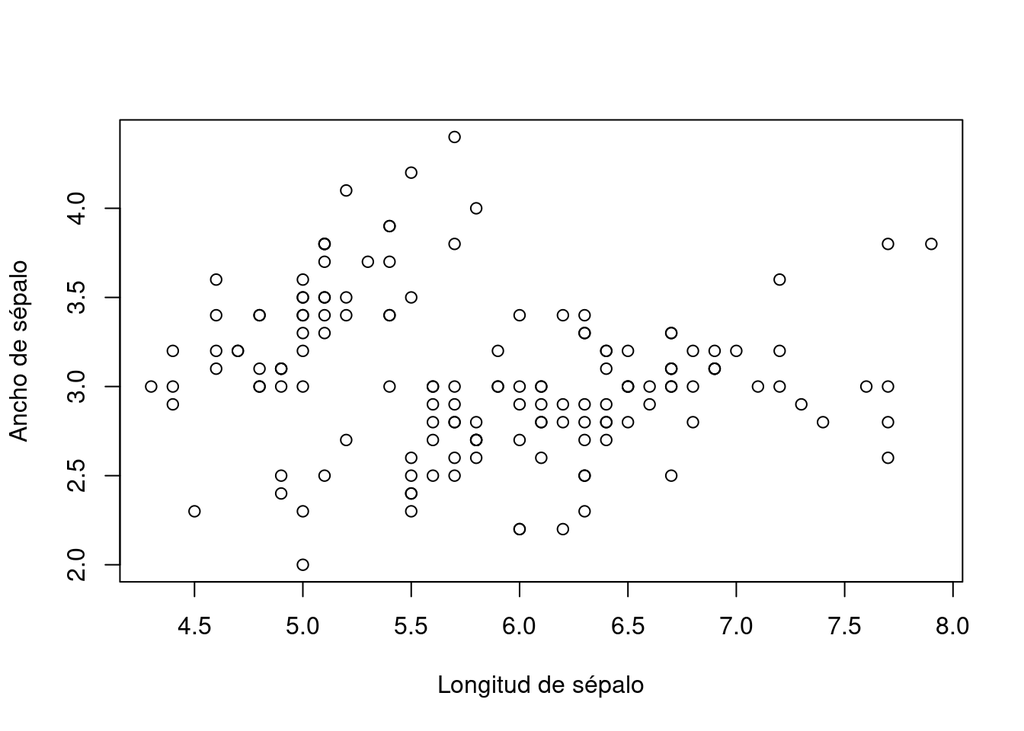

```r
plot(mydata$Sepalo.Longitud, mydata$Sepalo.Ancho, xlab = "Longitud de sépalo", ylab = "Ancho de sépalo")
```

¿Qué tipo de grafo produce `plot` solo con el conjunto de datos por argumento?

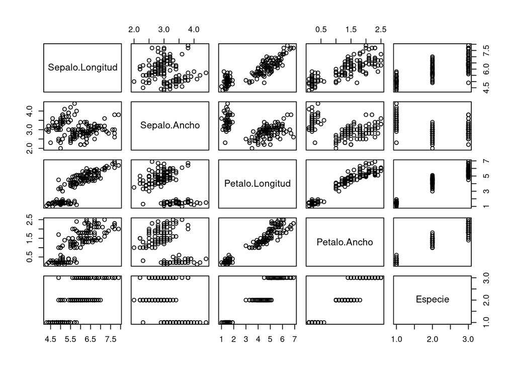

```r
plot(mydata)
```

También podemos ver todos los posibles pares con la función `pairs`.

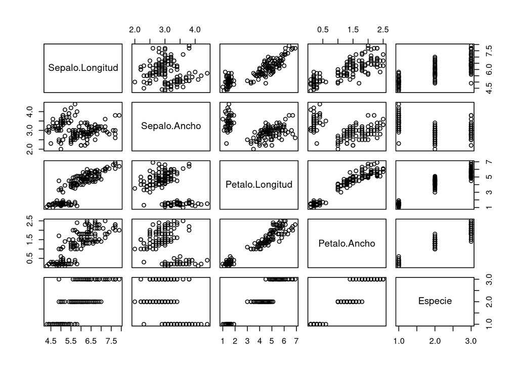

```r
pairs(mydata)
```

¿Qué análisis podemos incluir basado en el gráfico anterior?

A continuación, calculamos las estadísticas de Sepalo.Longitud de cada especie con la función aggregate().

```r
temp<-aggregate(Sepalo.Longitud ~ Especie, summary, data = mydata)
temp
```

```
##           Especie Sepalo.Longitud.Min. Sepalo.Longitud.1st Qu.
## 1     Iris-setosa                4.300                   4.800
## 2 Iris-versicolor                4.900                   5.600
## 3  Iris-virginica                4.900                   6.225
##   Sepalo.Longitud.Median Sepalo.Longitud.Mean Sepalo.Longitud.3rd Qu.
## 1                  5.000                5.006                   5.200
## 2                  5.900                5.936                   6.300
## 3                  6.500                6.588                   6.900
##   Sepalo.Longitud.Max.
## 1                5.800
## 2                7.000
## 3                7.900
```

Luego usamos la función boxplot() para trazar un diagrama de caja, para mostrar la mediana, el primer y tercer cuartil de una distribución (es decir, los puntos 50%, 25% y 75% en distribución acumulativa) y valores atípicos. La barra del medio indica el valor de la mediana. El cuadro muestra el rango intercuartílico (RIC), que es el rango de observación entre el 75% y el 25%.

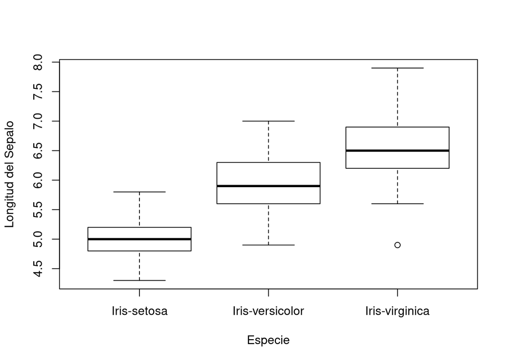

```r
boxplot(Sepalo.Longitud ~ Especie, data = mydata, xlab="Especie", ylab="Longitud del Sepalo")
```

El resultado muestra que las tres especies tienen diferentes distribuciones en su longitud de sépalo. “Virginica” tiende a tener una longitud de sépalo grande, “setosa” tiene una longitud de sépalo pequeño y “versicolor” se encuentra en el medio. Eso sugiere que esta variable se puede utilizar para predecir las especies de flores.

## Diagrama de dispersión

Se puede dibujar un diagrama de dispersión para dos variables numéricas con plot() como se muestra a continuación. Agregamos las variables a incluir en el diagram “mydata$” seguido de los nombres de las variables. En el siguiente código, los colores (col) y los símbolos (pch) de los puntos se establecen con la variable Especie.

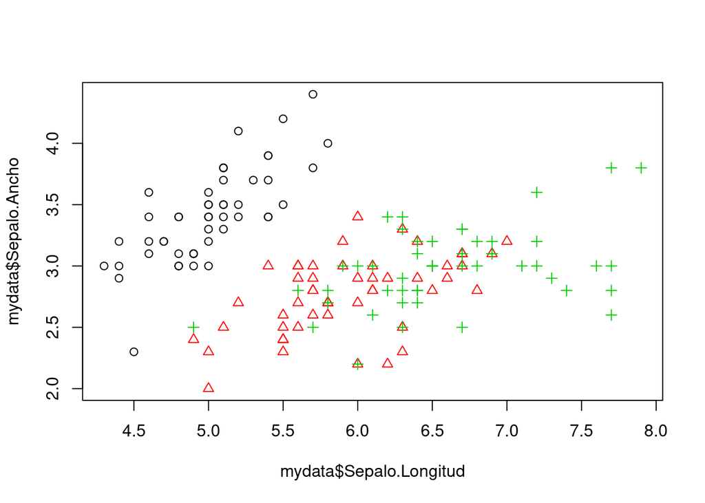

```r
plot(mydata$Sepalo.Longitud, mydata$Sepalo.Ancho, col=mydata$Especie, pch=as.numeric(mydata$Especie))
```

Para incluir una leyenda para los colores, ejecutar el siguiente código junto. La función plot es muy simple, y no puede manejar gráficos más complejos, en este caso cambiamos la forma de los puntos a `pch=16` para que presente los datos como puntos rellenos e incluirlos en la leyenda.

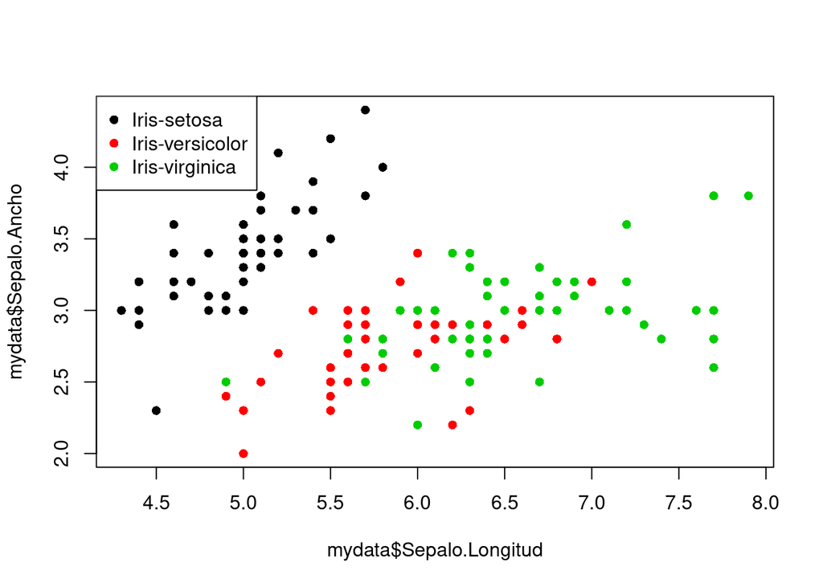

```r
# para incluir la leyenda en plot:
plot(mydata$Sepalo.Longitud, mydata$Sepalo.Ancho, col=mydata$Especie, pch=16)
legend("topleft", legend=levels(mydata$Especie), pch=16, col=unique(mydata$Especie))
```

Otras funciones más utilizadas son partes de paquetes que deben instalarse en R, y podremos usar asi la libreria incluida en el paquete. Un paquete que incluye funciones para visualizaciones es `ggplot2`. Instalamos el paquete una vez con `install.packages("ggplot2")` y al terminar podemos incluirl como libreria en nuestro código `library(ggplot2)`

```r
install.packages("ggplot2")
```

Ilustramos el uso de esta libreria con funciones como `qplot` y `ggplot`

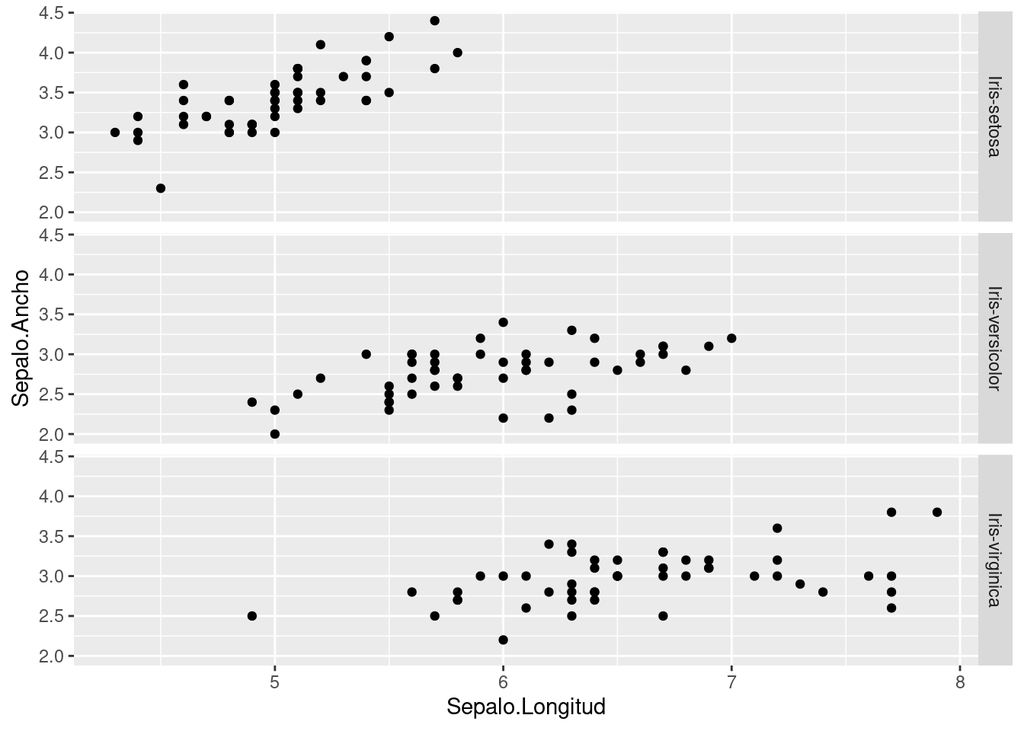

```r
library(ggplot2)
#qplot(mydata$Sepalo.Longitud, mydata$Sepalo.Ancho, facets =mydata$Especie) ESTA LINEA ME DIO ERROR EN CLASES
qplot(Sepalo.Longitud, Sepalo.Ancho, facets=Especie ~., data=mydata)
```

Ahora utilizando `ggplot` la función más usada para visualizaciones en R.

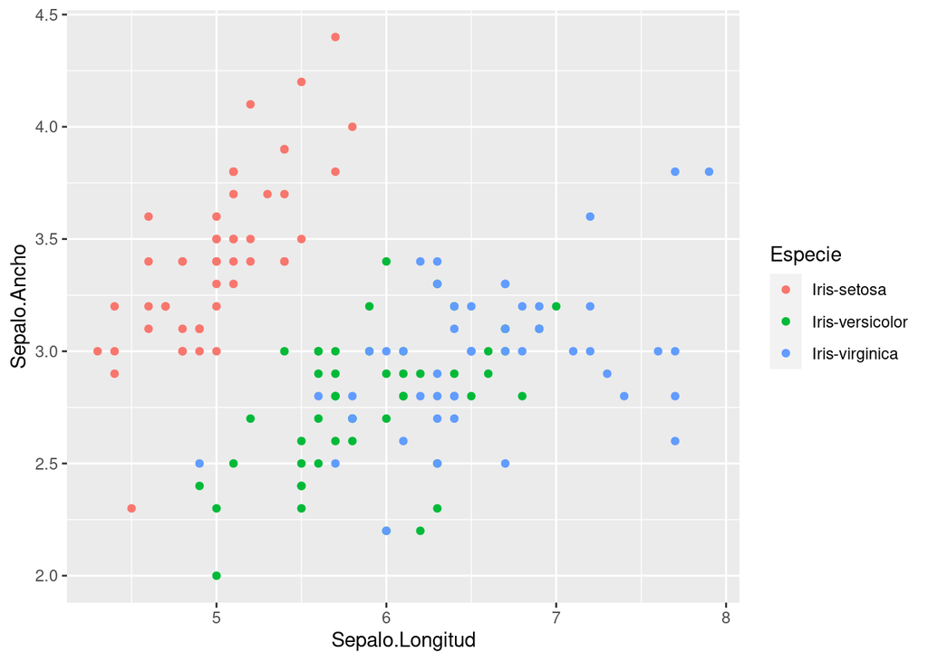

```r
ggplot(data=mydata)+geom_point(aes(x=Sepalo.Longitud,y=Sepalo.Ancho,colour=Especie))
```